```python
from __future__ import annotations

import matplotlib.pyplot as plt
import numpy as np
import pandas as pd

from mxlpy import (
    InitialAssignment,
    SteadyStateModelBuilder,
    cartesian_product,
    fit,
    mca,
    plot,
    scan,
)
from mxlpy.meta import generate_model_code_mxlweb
```

from __future__ import annotations import matplotlib.pyplot as plt import numpy as np import pandas as pd from mxlpy import ( InitialAssignment, SteadyStateModelBuilder, cartesian_product, fit, mca, plot, scan, ) from mxlpy.meta import generate_model_code_mxlweb

# Steady-state models

A `SteadyStateModelBuilder` describes a model without any dynamics: there are no variables, only parameters and quantities derived from them. This makes it a good fit for algebraic models, e.g. analytic steady-state solutions, response curves or allometric relationships.

Because there is nothing to integrate, a `SteadyStateModelBuilder` is never simulated. Instead it is *evaluated* directly, which is both simpler and much faster.

As an example we use an enzyme following Michaelis-Menten kinetics, which is competitively inhibited by \(I\)

\[ v = \frac{V_{\max} \cdot S}{K_m \left(1 + \frac{I}{K_i}\right) + S} \qquad V_{\max} = k_{cat} \cdot E_{tot}\]

## Building the model

Parameters and derived quantities work just like in the other builders. Parameters can also be initial assignments, and derived quantities can depend on each other in any order.

```python
def mul(a: float, b: float) -> float:
    return a * b


def apparent_km(km: float, i: float, ki: float) -> float:
    return km * (1 + i / ki)


def michaelis_menten(s: float, vmax: float, km: float) -> float:
    return vmax * s / (km + s)


def ratio(a: float, b: float) -> float:
    return a / b


def get_model() -> SteadyStateModelBuilder:
    return (
        SteadyStateModelBuilder()
        .add_parameters(
            {"kcat": 10.0, "e_tot": 0.5, "km": 2.0, "ki": 1.0, "S": 1.0, "I": 0.0}
        )
        .add_parameter("vmax", InitialAssignment(fn=mul, args=["kcat", "e_tot"]))
        .add_derived("km_app", fn=apparent_km, args=["km", "I", "ki"])
        .add_derived("v", fn=michaelis_menten, args=["S", "vmax", "km_app"])
        .add_derived("saturation", fn=ratio, args=["v", "vmax"])
    )


model = get_model()
model.derived
```

def mul(a: float, b: float) -> float: return a * b def apparent_km(km: float, i: float, ki: float) -> float: return km * (1 + i / ki) def michaelis_menten(s: float, vmax: float, km: float) -> float: return vmax * s / (km + s) def ratio(a: float, b: float) -> float: return a / b def get_model() -> SteadyStateModelBuilder: return ( SteadyStateModelBuilder() .add_parameters( {"kcat": 10.0, "e_tot": 0.5, "km": 2.0, "ki": 1.0, "S": 1.0, "I": 0.0} ) .add_parameter("vmax", InitialAssignment(fn=mul, args=["kcat", "e_tot"])) .add_derived("km_app", fn=apparent_km, args=["km", "I", "ki"]) .add_derived("v", fn=michaelis_menten, args=["S", "vmax", "km_app"]) .add_derived("saturation", fn=ratio, args=["v", "vmax"]) ) model = get_model() model.derived

|  | value | unit |
| --- | --- | --- |
| km_app | \(km \left(\frac{I}{ki} + 1.0\right)\) |  |
| v | \(\frac{S vmax}{S + km_{app}}\) |  |
| saturation | \(\frac{v}{vmax}\) |  |

## Evaluation

`evaluate` returns all derived values as a `pandas.Series`. This replaces the `Simulator` for this builder.

```python
model.evaluate()
```

model.evaluate()

```
km_app        2.000000
v             1.666667
saturation    0.333333
dtype: float64
```

Optionally, the parameters (including initial assignments) can be included as well

```python
model.evaluate(include_parameters=True)
```

model.evaluate(include_parameters=True)

```
kcat          10.000000
e_tot          0.500000
km             2.000000
ki             1.000000
S              1.000000
I              0.000000
vmax           5.000000
km_app         2.000000
v              1.666667
saturation     0.333333
dtype: float64
```

The model is a normal fluent builder, so you can update parameters and evaluate again

```python
model.update_parameter("I", 2.0).evaluate()
```

model.update_parameter("I", 2.0).evaluate()

```
km_app        6.000000
v             0.714286
saturation    0.142857
dtype: float64
```

## Parameter scans

`scan.steady_state` accepts a `SteadyStateModelBuilder` and evaluates it for every row of `to_scan`. It returns a `SteadyStateScan` holding one `Evaluation` per scanned value. Since there are no variables, the values are accessed via `combined` or `get_args`.

Nothing is integrated, so there is no integrator to configure and no `y0`. Time course and protocol scans are not available for this builder.

```python
res = scan.steady_state(
    get_model(),
    to_scan=pd.DataFrame({"S": np.geomspace(0.1, 100, 21)}),
)

fig, ax = plot.lines(res.combined.loc[:, ["v"]])
ax.set(xscale="log", xlabel="substrate / a.u.", ylabel="rate / a.u.")
plt.show()
```

res = scan.steady_state( get_model(), to_scan=pd.DataFrame({"S": np.geomspace(0.1, 100, 21)}), ) fig, ax = plot.lines(res.combined.loc[:, ["v"]]) ax.set(xscale="log", xlabel="substrate / a.u.", ylabel="rate / a.u.") plt.show()

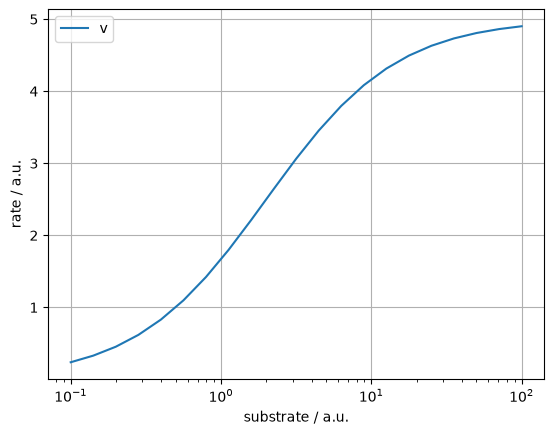

`get_args` can additionally include the parameters

```python
res.get_args(include_parameters=True).head()
```

res.get_args(include_parameters=True).head()

| S | kcat | e_tot | km | ki | S | I | vmax | km_app | v | saturation |
| --- | --- | --- | --- | --- | --- | --- | --- | --- | --- | --- |
| 0.100000 | 10.0 | 0.5 | 2.0 | 1.0 | 0.100000 | 0.0 | 5.0 | 2.0 | 0.238095 | 0.047619 |
| 0.141254 | 10.0 | 0.5 | 2.0 | 1.0 | 0.141254 | 0.0 | 5.0 | 2.0 | 0.329839 | 0.065968 |
| 0.199526 | 10.0 | 0.5 | 2.0 | 1.0 | 0.199526 | 0.0 | 5.0 | 2.0 | 0.453566 | 0.090713 |
| 0.281838 | 10.0 | 0.5 | 2.0 | 1.0 | 0.281838 | 0.0 | 5.0 | 2.0 | 0.617569 | 0.123514 |
| 0.398107 | 10.0 | 0.5 | 2.0 | 1.0 | 0.398107 | 0.0 | 5.0 | 2.0 | 0.830045 | 0.166009 |

Scanning multiple parameters works via `cartesian_product`, which yields a `pandas.MultiIndex`

```python
res = scan.steady_state(
    get_model(),
    to_scan=cartesian_product(
        {
            "S": np.geomspace(0.1, 100, 10),
            "I": np.linspace(0, 5, 6),
        }
    ),
)

fig, ax, _ = plot.heatmap_from_2d_idx(res.combined, "v")
ax.set(xlabel="S", ylabel="I", title="rate v")
plt.show()
```

res = scan.steady_state( get_model(), to_scan=cartesian_product( { "S": np.geomspace(0.1, 100, 10), "I": np.linspace(0, 5, 6), } ), ) fig, ax, _ = plot.heatmap_from_2d_idx(res.combined, "v") ax.set(xlabel="S", ylabel="I", title="rate v") plt.show()

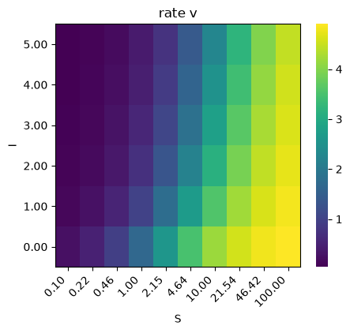

If an evaluation fails with an arithmetic error (e.g. a division by zero), the respective row is filled with `NaN` instead of failing the whole scan

```python
scan.steady_state(
    get_model(),
    to_scan=pd.DataFrame({"ki": [1.0, 0.0, 2.0]}),
).combined
```

scan.steady_state( get_model(), to_scan=pd.DataFrame({"ki": [1.0, 0.0, 2.0]}), ).combined

| ki | km_app | v | saturation |
| --- | --- | --- | --- |
| 1.0 | 2.0 | 1.666667 | 0.333333 |
| 0.0 | NaN | NaN | NaN |
| 2.0 | 2.0 | 1.666667 | 0.333333 |

## Fitting

`fit.steady_state` accepts a `SteadyStateModelBuilder` and fits its parameters to a `pandas.Series` of data. The data can contain any parameter or derived value.

Here we assume we measured the rate \(v\) and the saturation of the enzyme at \(S = 2\) and fit \(K_m\) and \(k_{cat}\).

```python
fitted = fit.steady_state(
    get_model().update_parameter("S", 2.0),
    p0={"km": 1.0, "kcat": 5.0},
    data=pd.Series({"v": 1.25, "saturation": 0.25}),
    minimizer=fit.LocalScipyMinimizer(),
).unwrap_or_err()
fitted.best_pars
```

fitted = fit.steady_state( get_model().update_parameter("S", 2.0), p0={"km": 1.0, "kcat": 5.0}, data=pd.Series({"v": 1.25, "saturation": 0.25}), minimizer=fit.LocalScipyMinimizer(), ).unwrap_or_err() fitted.best_pars

```
{'km': np.float64(6.000008381401803), 'kcat': np.float64(10.000006243050944)}
```

The returned `Fit` contains a copy of the model, which can be evaluated with the best parameters

```python
fitted.model.update_parameters(fitted.best_pars).evaluate()
```

fitted.model.update_parameters(fitted.best_pars).evaluate()

```
km_app        6.000008
v             1.249999
saturation    0.250000
dtype: float64
```

## Response coefficients

Response coefficients describe how much the derived values change if a parameter is perturbed. As the model is evaluated instead of simulated, these are just the (normalised) derivatives of `evaluate()`. For example, the rate \(v\) responds proportionally to \(k_{cat}\).

```python
mca.response_coefficients(get_model(), to_scan=["kcat", "km", "S"]).combined
```

mca.response_coefficients(get_model(), to_scan=["kcat", "km", "S"]).combined

|  | kcat | km | S |
| --- | --- | --- | --- |
| km_app | 0.0 | 1.000000 | 0.000000 |
| v | 1.0 | -0.666667 | 0.666667 |
| saturation | 0.0 | -0.666667 | 0.666667 |

## Export

`SteadyStateModelBuilder` models can be saved to the native `.mxl.json` format with `mxlpy.save` / `mxlpy.load`, and exported to [MxlWeb](https://github.com/Computational-Biology-Aachen/mxl-web), which evaluates them in the browser.

```python
print(generate_model_code_mxlweb(get_model()))
```

print(generate_model_code_mxlweb(get_model()))

```
import { SteadyStateModelBuilder } from "@computational-biology-aachen/mxlweb-core";
import { Add, Divide, Mul, Name, Num } from "@computational-biology-aachen/mxlweb-core/mathml";

export function initModel(): SteadyStateModelBuilder {
    return new SteadyStateModelBuilder()
      .addParameter("kcat", {
        value: 10.0,
        texName: 'kcat',
      })
      .addParameter("e_tot", {
        value: 0.5,
        texName: 'e\\_tot',
      })
      .addParameter("km", {
        value: 2.0,
        texName: 'km',
      })
      .addParameter("ki", {
        value: 1.0,
        texName: 'ki',
      })
      .addParameter("S", {
        value: 1.0,
        texName: 'S',
      })
      .addParameter("I", {
        value: 0.0,
        texName: 'I',
      })
      .addParameter("vmax", {
        value: new Mul([new Name("e_tot"), new Name("kcat")]),
        texName: 'vmax',
      })
      .addAssignment("km_app", {
        fn: new Mul([new Name("km"), new Add([new Num(1.0), new Divide([new Name("I"), new Name("ki")])])]),
        texName: 'km\\_app',
      })
      .addAssignment("v", {
        fn: new Divide([new Mul([new Name("S"), new Name("vmax")]), new Add([new Name("S"), new Name("km_app")])]),
        texName: 'v',
      })
      .addAssignment("saturation", {
        fn: new Divide([new Name("v"), new Name("vmax")]),
        texName: 'saturation',
      })
  }
```

## Current limitations

The `SteadyStateModelBuilder` supports every routine whose question makes sense without dynamics: steady-state scans, fits (including group, ensemble and joint fits), Monte Carlo methods, response coefficients and sensitivity analysis. Time courses, protocols and everything about reactions or fluxes don't apply to it.